# Python Workshop - Day 2

**Date**: 24 April 2021

**Instructor**: Andres Patrignani | Soil Water Processes | Department of Agronomy | Kansas State University

**Moderator**: Adrian Correndo

**Contact**: andrespatrignani@ksu.edu

Workshop organized by the Agronomy Graduate Students Association Stats & Programming Committee

## Import Modules

In this exercise we will the following Python modules:

- [Numpy](https://numpy.org)
- [Matplotlib](https://matplotlib.org)

```python
# Import modules
import numpy as np
import matplotlib.pyplot as plt
plt.style.use('seaborn')

# These modules are used at the very end of the tutorial
import glob
import pprint as pp
import pandas as pd
```

## NumPy arrays

Before diving into image analysis is important that we understand some basic concepts about representation of one-, two-, and three-dimensional arrays in Numpy.

```python
# One-dimensional array
A = np.array( [1,2,3] ) # One row with 3 elements
print(A)
print(A.shape)
print(type(A))
```

```
[1 2 3]
(3,)
<class 'numpy.ndarray'>
```

```python
# Two-dimensional array
B = np.array([ [1,2,3], [4,5,6] ]) # 2 rows by 3 columns
# B = np.array([ [1,2], [3,4], [5,6] ]) # 3 rows by 2 columns
print(B)
print(B.shape)
print(type(B))
```

```
[[1 2 3]
 [4 5 6]]
(2, 3)
<class 'numpy.ndarray'>
```

```python
# Three-dimensional array
C = np.zeros([5,5,3]) # 5 rows, 5 columns and 3 layers stacked behind each other
print(C)
print(C.shape)
print(type(C))
```

```
[[[0. 0. 0.]
  [0. 0. 0.]
  [0. 0. 0.]
  [0. 0. 0.]
  [0. 0. 0.]]

 [[0. 0. 0.]
  [0. 0. 0.]
  [0. 0. 0.]
  [0. 0. 0.]
  [0. 0. 0.]]

 [[0. 0. 0.]
  [0. 0. 0.]
  [0. 0. 0.]
  [0. 0. 0.]
  [0. 0. 0.]]

 [[0. 0. 0.]
  [0. 0. 0.]
  [0. 0. 0.]
  [0. 0. 0.]
  [0. 0. 0.]]

 [[0. 0. 0.]
  [0. 0. 0.]
  [0. 0. 0.]
  [0. 0. 0.]
  [0. 0. 0.]]]
(5, 5, 3)
<class 'numpy.ndarray'>
```

## NumPy element-wise operations

```python
# Vectorized operations is one one of the main advanges of the NumPy module
# These type of operations cannot be done with regular Python lists.
M = np.array([2,4,6])
N = np.array([1,3,5])

# Note that the result occurrs for each element
print(M + N) # Addition
print(M - N) # Subtraction
print(M * N) # Multiplication
print(M / N) # Division
print(M ** N) # Exponentiation
```

```
[ 3  7 11]
[1 1 1]
[ 2 12 30]
[2.         1.33333333 1.2       ]
[   2   64 7776]
```

## Read image

```python
# Read image
RGB = plt.imread('soybeans_20200819_090000.jpg') # Image collected on 19-August-2020 at 9 AM
```

```python
# Check image dimensions and size
print(RGB.shape)
print(RGB.size) # Total number of pixels
```

```
(1920, 2560, 3)
14745600
```

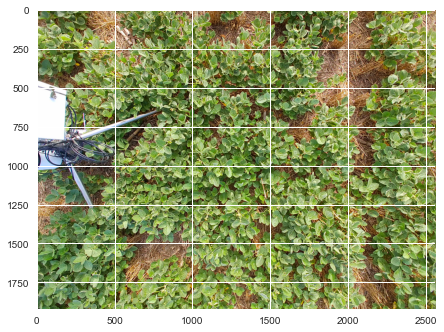

```python
# Display image
plt.figure()
plt.imshow(RGB)
plt.show()
```

## Slicing an image

```python
# Access first pixel of red band
RGB[0,0,0]

# This is the intensity of the red band (range 0 to 255)
```

```
184
```

```python
# Access all bands for first pixel
RGB[0,0,:]

# Note that the type is "unsigned integer of 8 bits"
# There are 256 possible representations (2^8 = 256) for each pixel in each band. In this case from 0 to 255.
```

```
array([184, 207, 127], dtype=uint8)
```

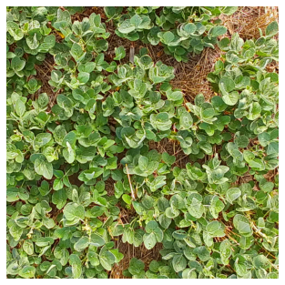

```python
# Slice to remove tripod legs
RGB_patch = RGB[500:1500, 1000:2000] # A 1000 by 1000 pixels patch

plt.figure()
plt.imshow(RGB_patch)
plt.axis('off')
plt.show()
```

```python
# Slice each band into a separate variable
# Convert each band from unsigned integers to floating point to allow math operations later
R = np.float32(RGB_patch[:,:,0]) # Red band
G = np.float32(RGB_patch[:,:,1]) # Green band
B = np.float32(RGB_patch[:,:,2]) # Bue band
```

## Show image bands

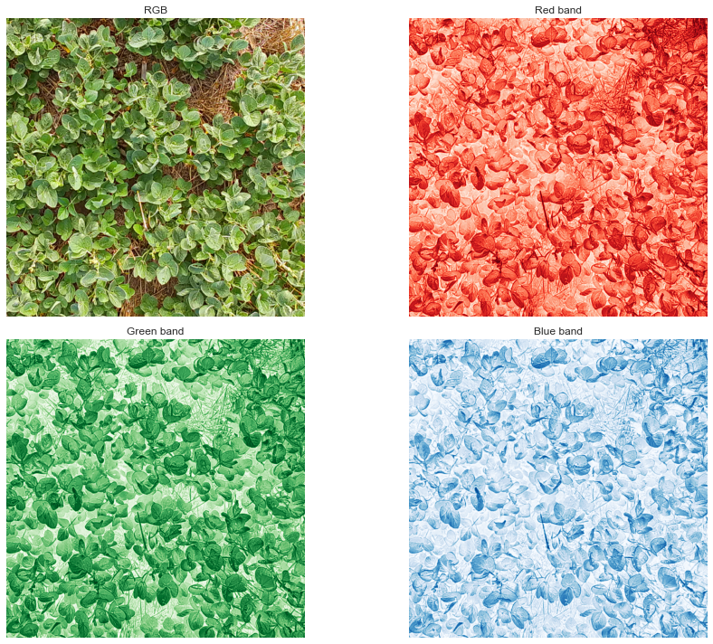

```python
# Create plots for each band
plt.figure(figsize=(14,10))

plt.subplot(2,2,1)
plt.imshow(RGB_patch)
plt.title('RGB')
plt.axis('off')

plt.subplot(2,2,2)
plt.imshow(R, cmap='Reds')
plt.title('Red band')
plt.axis('off')

plt.subplot(2,2,3)
plt.imshow(G, cmap='Greens')
plt.title('Green band')
plt.axis('off')

plt.subplot(2,2,4)
plt.imshow(B, cmap='Blues')
plt.title('Blue band')
plt.axis('off')

plt.tight_layout()
#plt.savefig('mosaic.jpg', dpi=300)
plt.show()
```

## Computing green canopy cover

In this step we will implement the routine used by the Canopeo app (Patrignani and Ochsner, 2015)

```python
# Canopeo routine
#np.seterr(divide='ignore', invalid='ignore')

RG_ratio = R/G
BG_ratio = B/G
ExG = 2*G - R - B
```

```
<ipython-input-14-604882a464c8>:4: RuntimeWarning: divide by zero encountered in true_divide
  RG_ratio = R/G
<ipython-input-14-604882a464c8>:5: RuntimeWarning: invalid value encountered in true_divide
  BG_ratio = B/G
```

> Warnings don't stop execution, but should not be ignored. Enabling the line `np.seterr(divide='ignore', invalid='ignore')` will remove the warning message, but I personally prefer to keep it as a reminder that we are getting values out of range.

```python
# Replace infinity values as a consequence of the division by zero by a placeholder that won't affect our goal.
# Since we know that ratios of about 0.95 are effective for classifying green cover, then a placeholder of 10 should
# not have any impact on the thresholding.

inf_placeholder = 10
RG_ratio = np.where(np.isinf(RG_ratio), inf_placeholder , RG_ratio);
BG_ratio = np.where(np.isinf(BG_ratio), inf_placeholder , BG_ratio);
```

```python
# Check resulting array dimensions
print(RG_ratio.shape)
print(BG_ratio.shape)
print(ExG.shape)
```

```
(1000, 1000)
(1000, 1000)
(1000, 1000)
```

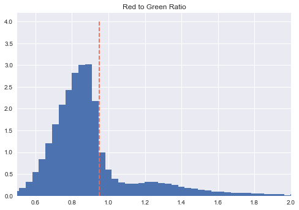

```python
# Create histograms
plt.figure()
plt.hist(RG_ratio.flatten(), bins='scott', density=True)
plt.xlim(0.5,2)
plt.title('Red to Green Ratio')
plt.vlines(0.95, ymin=0, ymax=4, colors='tomato', linestyles='dashed')
plt.show()
```

```python
# Quantify percentage of green canopy cover
BW = np.logical_and(RG_ratio < 0.95, BG_ratio < 0.95, ExG > 20)
canopy_cover = np.sum(BW.flatten()) / BW.size * 100

print(round(canopy_cover, 2))
```

```
75.72
```

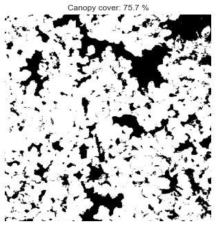

```python
# Create resulting figure
plt.figure()
plt.imshow(BW, cmap='binary_r')
plt.title( 'Canopy cover: ' + str(round(canopy_cover,1)) + ' %' )
plt.axis('off')
plt.show()
```

## Define a function

```python
## Define a function

# We will suppress the message in the function to avoid the message every time we call the function
np.seterr(divide='ignore', invalid='ignore')

def canopeo(img, RG=0.95, BG=0.95, EG=20):
    """Function for quantifying green canopy cover"""

    RG_ratio = img[:,:,0] / img[:,:,1]
    RG_ratio = np.where(np.isinf(RG_ratio), 10, RG_ratio);

    BG_ratio = img[:,:,2] / img[:,:,1]
    BG_ratio = np.where(np.isinf(BG_ratio), 10, BG_ratio);

    ExG = 2*img[:,:,1] - img[:,:,0] - img[:,:,2]
    BW = np.logical_and(RG_ratio < RG, BG_ratio < BG, ExG > EG)
    canopy_cover = np.sum(BW.flatten()) / BW.size * 100
    return round(canopy_cover,2)
```

## Call a function

```python
# Call the function with the full image
print(canopeo(RGB))

# Call again with the cropped patch
print(canopeo(RGB_patch))
```

```
66.32
75.72
```

## Read multiple images

Now that we have a function we can re-use the code to process multiple images.

```python
## Load multiple images
filenames = glob.glob('*.jpg') # If files are not sorted by default, use sorted(glob.glob('*.jpg'))
print(filenames)
```

```
['soybeans_20200819_090000.jpg', 'soybeans_20200819_120000.jpg', 'soybeans_20200819_150000.jpg', 'soybeans_20200819_180000.jpg']
```

```python
# Create empty dictionary
CC = {'filename':[], 'timestamp': [], 'CC':[]}

# Iterate over each filename, read image, and save canopy cover in dcitionary
for file in filenames:
    I = plt.imread(file)
    CC['filename'].append(file)
    CC['CC'].append(canopeo(I))

    # Not the most elegant solution to split a string,
    # but it works without a separate module or more complex statements
    file_no_ext = file.split('.') # First split string at the period
    file_no_ext_parts = file_no_ext[0].split('_') # Then split filename at each underscore
    timestamp_str = file_no_ext_parts[1] + file_no_ext_parts[2]
    timestamp = pd.to_datetime(timestamp_str, format='%Y%m%d%H%M%S')
    CC['timestamp'].append(timestamp)

# Print dictionary using the Pretty Print module (not necessary to display a dictionary, but it helps with visualization)
pp.pprint(CC)
```

```
{'CC': [66.32, 54.37, 43.14, 61.13],
 'filename': ['soybeans_20200819_090000.jpg',
              'soybeans_20200819_120000.jpg',
              'soybeans_20200819_150000.jpg',
              'soybeans_20200819_180000.jpg'],
 'timestamp': [Timestamp('2020-08-19 09:00:00'),
               Timestamp('2020-08-19 12:00:00'),
               Timestamp('2020-08-19 15:00:00'),
               Timestamp('2020-08-19 18:00:00')]}
```

## Dictionary to Pandas DataFrame

```python
df = pd.DataFrame(CC)
df
```

|  | filename | timestamp | CC |
| --- | --- | --- | --- |
| 0 | soybeans_20200819_090000.jpg | 2020-08-19 09:00:00 | 66.32 |
| 1 | soybeans_20200819_120000.jpg | 2020-08-19 12:00:00 | 54.37 |
| 2 | soybeans_20200819_150000.jpg | 2020-08-19 15:00:00 | 43.14 |
| 3 | soybeans_20200819_180000.jpg | 2020-08-19 18:00:00 | 61.13 |

## Practice

- Make the `canopeo` function return both the canopy cover and the classified image (`BW`) image.
- Create a figure with four by two subplots showing the images of soybeans under stress and their respective classified image. Add to the title of each original image the timestamp and to each classified image the percentage of green canopy cover.

## Where to go from here

Python has a large ecosystem of libraries and I'm sure that there is one for your project. Below is a not exhaustive list of well-established modules that may be helpful for your project:

- [Scikit Image](https://scikit-image.org/): An extensive module for image analysis. Very well dcoumented following peer-reviewed articles and with a clear and easy to understand syntax.
- [Scikit-learn](https://scikit-learn.org/stable/): a great and well-documented module for clustering, machine learning, regression, and classification.
- [SciPy](https://www.scipy.org/): A keystone of the Python scientific environemnt. From signal processing, interpolation (the interpolation in Pandas is based on SciPy) to statistical analysis, this module is one the great Python gems out there.
- [Statsmodels](https://www.statsmodels.org/stable/index.html): a module for implementing generalized linear models, mixed models, and analysis of variance. If you work with replicated experiments either in the field or the lab, then this module will provide the tools that we use in SAS.
- [xarray](http://xarray.pydata.org/en/stable/): A handy library for multidimensional datasets like remote sensing images. The module handles files like GeoTiffs and NetCDF files.
- [Plotly](https://plotly.com/python/), [Holoviews](https://holoviews.org/), and [Seaborn](https://seaborn.pydata.org/index.html): These are three plotting libraries that are worth taking a look. Plotly and Holoviews provide interactivity. Seaborn is built around Matplotlib and allows users to create common statistical plots in one or few lines. If you like the style of R's `ggplot` module, then with Seaborn you will feel at home.
- [PyNotes in Agriscience](https://soilwater.github.io/pynotes-agriscience): A set of Jupyter Notebooks for doing common tasks in agricultural sciences. While this is still udner development, examples use real datasets collected in the field and the content is aimed at students learning how to code.

## References

Patrignani, A. and Ochsner, T.E., 2015. Canopeo: A powerful new tool for measuring fractional green canopy cover. Agronomy Journal, 107(6), pp.2312-2320.

Van Der Walt, S., Colbert, S.C. and Varoquaux, G., 2011. The NumPy array: a structure for efficient numerical computation. Computing in science & engineering, 13(2), pp.22-30.